# Spatio-temporal variograms

Guillaume Blanchet & Steve Vissault

November 21th, 2019

# Prepare the R environment

We load the packages needed for this practice.

```r
# Spatial
library(sf)
library(sp) # for some analysis
library(dplyr)
# Analysis
library(gstat)
library(spacetime)
# visualization
library(mapview)
```

## Get access to the data

Download PM10 air quality data

# Load data

For this section, we will use the Air quality data obtained from the airBase European air quality data base. Daily averages for rural background stations in Germany, 1998-2009. Using a nationwide network of monitoring sites, EPA has developed ambient air quality trends for particle pollution, also called Particulate Matter (PM). PM10 used in this dataset describes inhalable particles, with diameters that are generally 10 micrometers and smaller.

```r
pm10 <- readRDS("./assets/data/air.rds")
head(pm10)
```

```
##   station_id   pm10      dates      lng      lat
## 1    DEBB051  8.688 2001-06-08 14.05746 52.54136
## 2    DEBB051  7.354 2001-09-10 14.05746 52.54136
## 3    DEBB051 15.729 2001-10-10 14.05746 52.54136
## 4    DEBB051 26.312 2001-05-03 14.05746 52.54136
## 5    DEBB051 13.958 2001-10-28 14.05746 52.54136
## 6    DEBB051 39.188 2001-10-16 14.05746 52.54136
```

```r
pm10_20090306 <- st_as_sf(subset(pm10, dates == "2009-03-06") ,coords = c("lng", "lat"), crs = 4326)
mapview(pm10_20090306, zcol = "pm10")
```

[interactive chart not shown]

# Prepare the data

To reduce the computation time, we focus on the period 2005-2010.

```r
pm10_2005_2010 <- subset(pm10, dates > as.Date("2005-01-01") &
                                     dates < as.Date("2010-12-31"))

STIDF_pm10_2005_2010 <- stConstruct(pm10_2005_2010, c("lng","lat"),"dates", crs = CRS("+init=epsg:4326"))
STFDF_pm10_2005_2010 <- as(STIDF_pm10_2005_2010, "STFDF")
summary(STFDF_pm10_2005_2010)
```

```
## Object of class STFDF
##  with Dimensions (s, t, attr): (53, 1825, 2)
## [[Spatial:]]
## Object of class SpatialPoints
## Coordinates:
##          min      max
## lng  6.28107 14.78617
## lat 47.80847 54.92497
## Is projected: FALSE
## proj4string :
## [+init=epsg:4326 +proj=longlat +datum=WGS84 +no_defs +ellps=WGS84
## +towgs84=0,0,0]
## Number of points: 53
## [[Temporal:]]
##      Index              timeIndex
##  Min.   :2005-01-02   Min.   :   1
##  1st Qu.:2006-04-03   1st Qu.: 457
##  Median :2007-07-03   Median : 913
##  Mean   :2007-07-03   Mean   : 913
##  3rd Qu.:2008-10-01   3rd Qu.:1369
##  Max.   :2009-12-31   Max.   :1825
## [[Data attributes:]]
##    station_id         pm10
##  DETH026: 1821   Min.   :  0.560
##  DENI063: 1815   1st Qu.:  9.275
##  DEBY047: 1815   Median : 13.854
##  DEMV017: 1814   Mean   : 16.261
##  DEUB028: 1814   3rd Qu.: 20.333
##  (Other):65675   Max.   :269.079
##  NA's   :21971   NA's   :21971
```

# Build empricial spatio-temporal variogram

```r
pm10_vario <- variogram(pm10~1, STFDF_pm10_2005_2010, width=20, cutoff = 200, tlags=0:5)
```

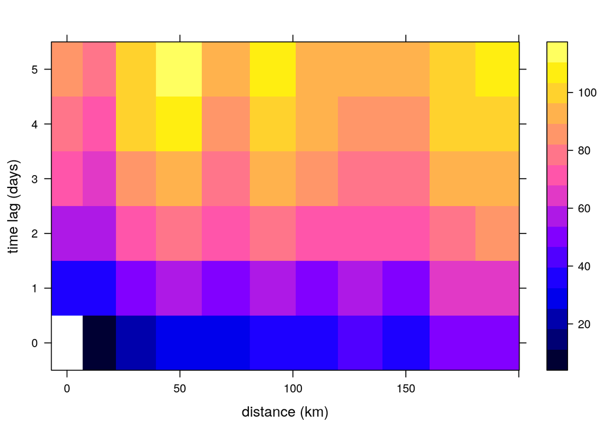

```r
plot(pm10_vario)
```

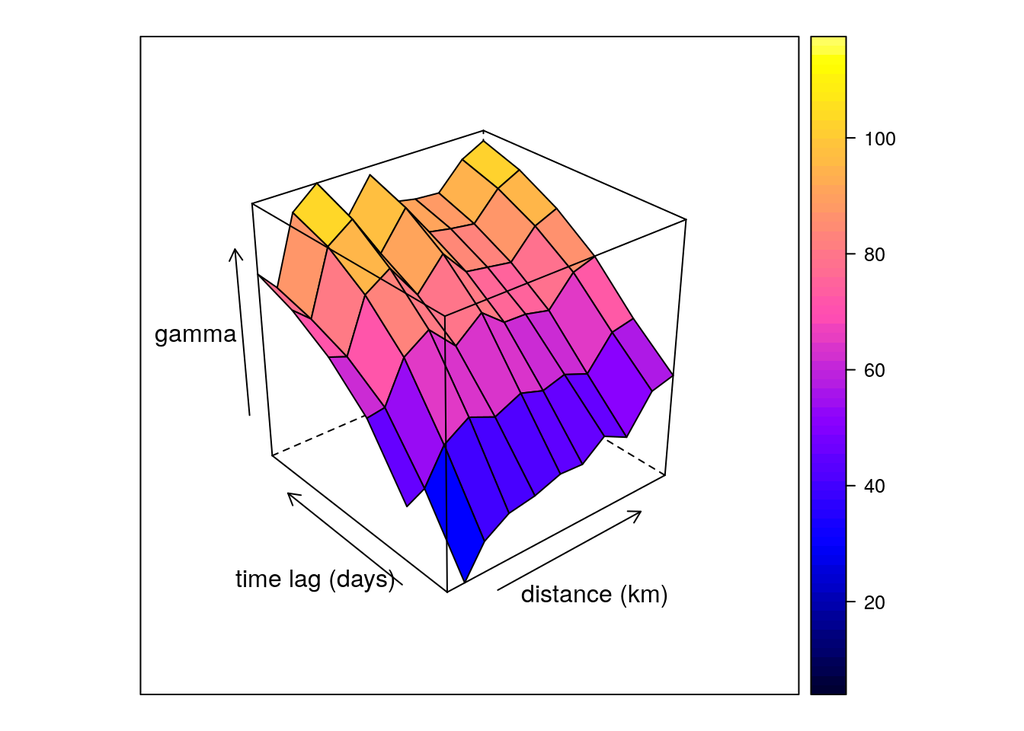

```r
plot(pm10_vario, wireframe = TRUE)
```

## Model variogram

### Declare the model

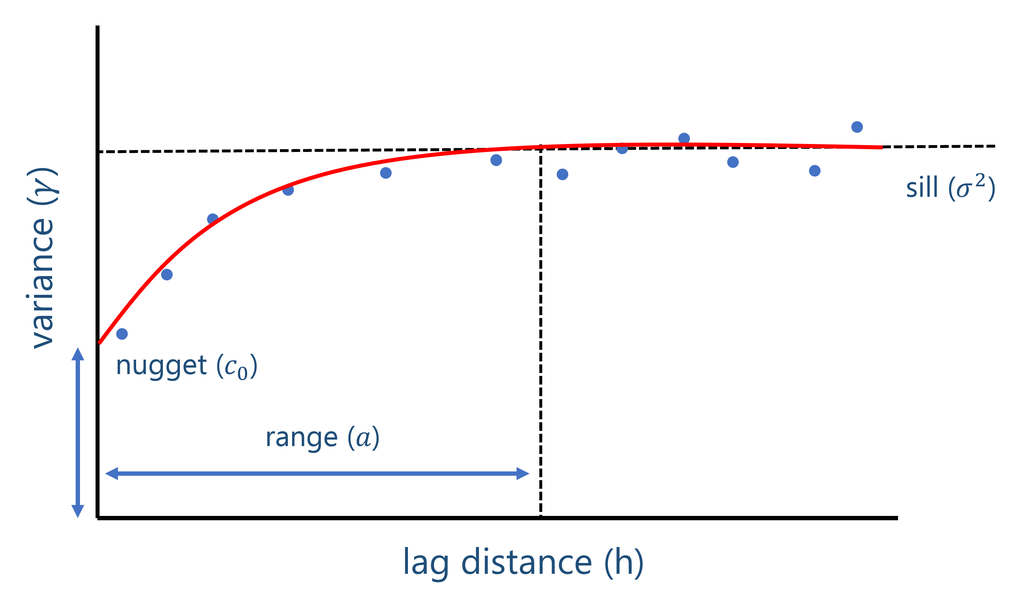

The argument `sill` that is supplied to `vgmST` (below) defines the joint spatio-temporal sill.

```r
# Declare the model variogram
separableModel <- vgmST("separable",
                        method = "Nelder-Mead", # no lower & upper needed
                        space = vgm(psill = 0.9, model = "Exp", range = 123, nugget = 0.1),
                        time = vgm(psill = 0.9, model = "Exp", range = 2.9, nugget = 0.1),
                        sill = 100)
```

The function `fit.StVariogram` will use the `optim` function to optimize and find the best set of parameters for the model variogram using the mean squared errors.

```r
# fit the separableModel variogram
separableModel <- fit.StVariogram(pm10_vario, separableModel,
                                  method="BFGS")
# metric model
metricModel <- vgmST("metric",
                     method = "Nelder-Mead", # no lower & upper needed
                     joint=vgm(0.9, "Exp", 123, 0.1),
                     stAni=100)

metricModel <- fit.StVariogram(pm10_vario, metricModel,
                                  method="BFGS")
```

But many other possibilities

```r
# product sum model: spatial and temporal nugget will be ignored and kept
# constant at 0. Only a joint nugget is used.
prodSumModel <- vgmST("productSum",
                      space=vgm(39, "Sph", 343, 0),
                      time= vgm(36, "Exp",   3, 0),
                      k=15)

# sum metric model: spatial, temporal and joint nugget will be estimated
sumMetricModel <- vgmST("sumMetric",
                        space=vgm( 6.9, "Lin", 200, 3.0),
                        time =vgm(10.3, "Lin",  15, 3.6),
                        joint=vgm(37.2, "Exp",  84,11.7),
                        stAni=77.7)

# simplified sumMetric model, only a overall nugget is fitted. The spatial,
# temporal and jont nuggets are set to 0.
simpleSumMetricModel <- vgmST("simpleSumMetric",
                              space=vgm(20,"Lin", 150, 0),
                              time =vgm(20,"Lin", 10,  0),
                              joint=vgm(20,"Exp", 150, 0),
                              nugget=1, stAni=15)
```

### Assess model quality

You can get the mean squared errors within the output of the function `fit.StVariogram()` with the following command line and compare them.

```r
attr(separableModel,"optim")$value
```

```
## [1] 46.4424
```

```r
attr(metricModel,"optim")$value
```

```
## [1] 60.661
```

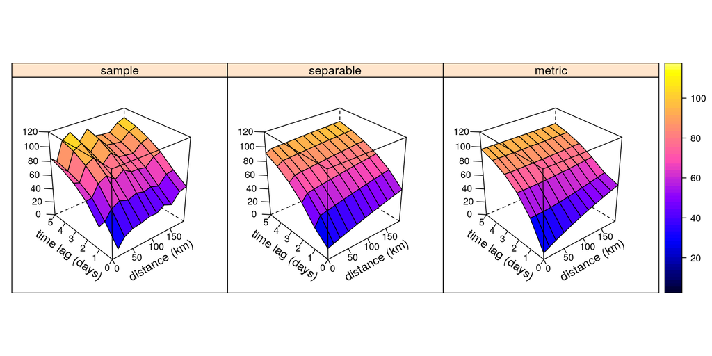

```r
library(lattice)
plot(pm10_vario, list(separableModel, metricModel), all=T, wireframe=T, zlim=c(0,120),
    zlab=NULL,
    xlab=list("distance (km)", rot=30),
    ylab=list("time lag (days)", rot=-35),
    scales=list(arrows=F, z = list(distance = 5)))
```

## Spatio-temporal kriging

We subset 3 days within the STSDF in order to reduce the krigging computation time.

```r
STFDF_pm10_3d <- STFDF_pm10_2005_2010[,"2005-06-01::2005-06-03"]
str(STFDF_pm10_3d)
```

```
## Formal class 'STFDF' [package "spacetime"] with 4 slots
##   ..@ data   :'data.frame':  159 obs. of  2 variables:
##   .. ..$ station_id: Factor w/ 46 levels "DEBB053","DEBE032",..: 1 2 3 4 5 6 7 8 9 10 ...
##   .. ..$ pm10      : num [1:159] 11.9 12.4 15.8 14.8 14.3 ...
##   ..@ sp     :Formal class 'SpatialPoints' [package "sp"] with 3 slots
##   .. .. ..@ coords     : num [1:53, 1:2] 14.02 13.23 13.65 9.57 7.76 ...
##   .. .. .. ..- attr(*, "dimnames")=List of 2
##   .. .. .. .. ..$ : chr [1:53] "659" "6179" "9814" "11736" ...
##   .. .. .. .. ..$ : chr [1:2] "lng" "lat"
##   .. .. ..@ bbox       : num [1:2, 1:2] 6.28 47.81 14.79 54.92
##   .. .. .. ..- attr(*, "dimnames")=List of 2
##   .. .. .. .. ..$ : chr [1:2] "lng" "lat"
##   .. .. .. .. ..$ : chr [1:2] "min" "max"
##   .. .. ..@ proj4string:Formal class 'CRS' [package "sp"] with 1 slot
##   .. .. .. .. ..@ projargs: chr "+init=epsg:4326 +proj=longlat +datum=WGS84 +no_defs +ellps=WGS84 +towgs84=0,0,0"
##   ..@ time   :An 'xts' object on 2005-06-01/2005-06-03 containing:
##   Data: int [1:3, 1] 151 152 153
##  - attr(*, "dimnames")=List of 2
##   ..$ : NULL
##   ..$ : chr "timeIndex"
##   Indexed by objects of class: [Date] TZ: UTC
##   xts Attributes:
##  NULL
##   ..@ endTime: POSIXct[1:3], format: "2005-06-02" ...
```

```r
# Convert to STIDF class
STIDF_pm10_3d <- as(STFDF_pm10_3d, "STIDF")
```

We create the empty spatial grid.

```r
library(raster)
sp_area <- STFDF_pm10_3d@sp
proj <- proj4string(STFDF_pm10_3d@sp)
rs_area <- raster(extent(sp_area), res = 0.05)
sp_grid_area <- SpatialPoints(rasterToPoints(rs_area), CRS(proj))
```

Perform the krigging

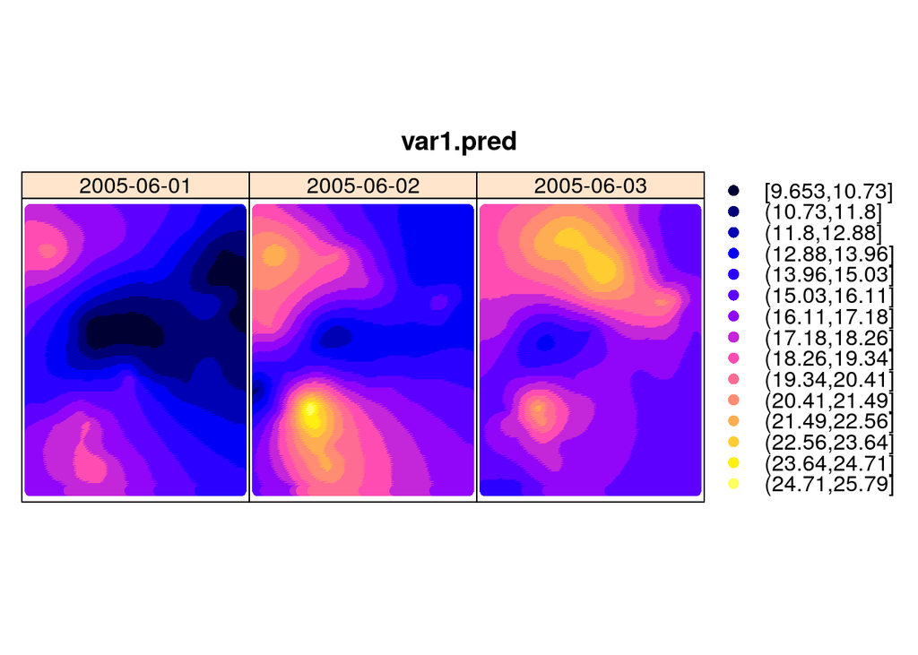

```r
DE_pred <- STF(sp=sp_grid_area, time=STFDF_pm10_3d@time)
DE_kriged <- krigeST(pm10~1, data=STIDF_pm10_3d, newdata=DE_pred,
                    modelList=separableModel)

stplot(DE_kriged)
```